# Work Integrated Learning Programmes Division M.Tech (Data Science and Engineering) Data Visualization And Interpretation (DSECL ZG555)) First Semester, 2024-25

## Assignment 2 – PS4 [Weightage 13%]

# Instructions

1. Do not change the name of the data file that is shared with the problem statement.
2. If intermediate data files are created, retain in the present working directory and attach them during submission.
3. Retain the data file in the same directory as that of this workbook.
4. Retain the Visualizations that is produced in the file. Don't clear them away.
5. All the visuals should adhere to the visualization principles learnt in the Course and must be presentation ready. Most effective visuals would fetch maximum credits
6. Submissions done via means other than CANVAS will strictly be NOT graded.

## Group No: 27

| FULL NAME | BITS ID |
| --- | --- |
| IPPA BHARATH KUMAR | 2023dc04119 |
| RAYANAPATI SOWMYA | 2023dc04122 |
| SUPRITHA S | 2023dc04161 |
| VINEETH PV | 2023dc04114 |

# Objective

#### Analyse the performance in IPL matches over past years

# Download and Prep the Data: 1 Mark

#### Import the libraries needed

```python
import pandas as pd
import numpy as np
import matplotlib.pyplot as plt
import seaborn as sns
import warnings
warnings.simplefilter(action='ignore', category=FutureWarning)
```

#### Load data and store in dataframe

```python
df_balls = pd.read_csv('dvi-a2-ps4-data1.csv')  # Ball-by-ball data
df_matches = pd.read_csv('dvi-a2-ps4-data2.csv')  # Match summary data
```

#### Display the first five items in the datasets.

```python
# Display the first five rows of both datasets
print("First 5 rows of Ball-by-Ball Data:")
display(df_balls.head())

print("\nFirst 5 rows of Match Summary Data:")
display(df_matches.head())
```

```
First 5 rows of Ball-by-Ball Data:
```

|  | match_id | inning | batting_team | bowling_team | over | ball | batsman | non_striker | bowler | is_super_over | ... | bye_runs | legbye_runs | noball_runs | penalty_runs | batsman_runs | extra_runs | total_runs | player_dismissed | dismissal_kind | fielder |
| --- | --- | --- | --- | --- | --- | --- | --- | --- | --- | --- | --- | --- | --- | --- | --- | --- | --- | --- | --- | --- | --- |
| 0 | 1 | 1 | Sunrisers Hyderabad | Royal Challengers Bangalore | 1 | 1 | DA Warner | S Dhawan | TS Mills | 0 | ... | 0 | 0 | 0 | 0 | 0 | 0 | 0 | NaN | NaN | NaN |
| 1 | 1 | 1 | Sunrisers Hyderabad | Royal Challengers Bangalore | 1 | 2 | DA Warner | S Dhawan | TS Mills | 0 | ... | 0 | 0 | 0 | 0 | 0 | 0 | 0 | NaN | NaN | NaN |
| 2 | 1 | 1 | Sunrisers Hyderabad | Royal Challengers Bangalore | 1 | 3 | DA Warner | S Dhawan | TS Mills | 0 | ... | 0 | 0 | 0 | 0 | 4 | 0 | 4 | NaN | NaN | NaN |
| 3 | 1 | 1 | Sunrisers Hyderabad | Royal Challengers Bangalore | 1 | 4 | DA Warner | S Dhawan | TS Mills | 0 | ... | 0 | 0 | 0 | 0 | 0 | 0 | 0 | NaN | NaN | NaN |
| 4 | 1 | 1 | Sunrisers Hyderabad | Royal Challengers Bangalore | 1 | 5 | DA Warner | S Dhawan | TS Mills | 0 | ... | 0 | 0 | 0 | 0 | 0 | 2 | 2 | NaN | NaN | NaN |

5 rows × 21 columns

```
First 5 rows of Match Summary Data:
```

|  | id | season | city | date | team1 | team2 | toss_winner | toss_decision | result | dl_applied | winner | win_by_runs | win_by_wickets | player_of_match | venue | umpire1 | umpire2 | umpire3 |
| --- | --- | --- | --- | --- | --- | --- | --- | --- | --- | --- | --- | --- | --- | --- | --- | --- | --- | --- |
| 0 | 1 | 2017 | Hyderabad | 2017-04-05 | Sunrisers Hyderabad | Royal Challengers Bangalore | Royal Challengers Bangalore | field | normal | 0 | Sunrisers Hyderabad | 35 | 0 | Yuvraj Singh | Rajiv Gandhi International Stadium, Uppal | AY Dandekar | NJ Llong | NaN |
| 1 | 2 | 2017 | Pune | 2017-04-06 | Mumbai Indians | Rising Pune Supergiant | Rising Pune Supergiant | field | normal | 0 | Rising Pune Supergiant | 0 | 7 | SPD Smith | Maharashtra Cricket Association Stadium | A Nand Kishore | S Ravi | NaN |
| 2 | 3 | 2017 | Rajkot | 2017-04-07 | Gujarat Lions | Kolkata Knight Riders | Kolkata Knight Riders | field | normal | 0 | Kolkata Knight Riders | 0 | 10 | CA Lynn | Saurashtra Cricket Association Stadium | Nitin Menon | CK Nandan | NaN |
| 3 | 4 | 2017 | Indore | 2017-04-08 | Rising Pune Supergiant | Kings XI Punjab | Kings XI Punjab | field | normal | 0 | Kings XI Punjab | 0 | 6 | GJ Maxwell | Holkar Cricket Stadium | AK Chaudhary | C Shamshuddin | NaN |
| 4 | 5 | 2017 | Bangalore | 2017-04-08 | Royal Challengers Bangalore | Delhi Daredevils | Royal Challengers Bangalore | bat | normal | 0 | Royal Challengers Bangalore | 15 | 0 | KM Jadhav | M Chinnaswamy Stadium | NaN | NaN | NaN |

#### Find out how many entries there are in the datasets.

```python
# Number of entries in the datasets
print(f"Ball-by-Ball data count: {df_balls.shape[0]}")
print(f"Match Summary data count: {df_matches.shape[0]}")
```

```
Ball-by-Ball data count: 150460
Match Summary data count: 636
```

#### Find out what type of variables you are dealing with. This will help you find the right visualization method for that variable.

```python
# Display data types of variables in both datasets
print("Data Types in Ball-by-Ball Dataset:")
print(df_balls.dtypes)

print("\nData Types in Match Summary Dataset:")
print(df_matches.dtypes)
```

```
Data Types in Ball-by-Ball Dataset:
match_id             int64
inning               int64
batting_team        object
bowling_team        object
over                 int64
ball                 int64
batsman             object
non_striker         object
bowler              object
is_super_over        int64
wide_runs            int64
bye_runs             int64
legbye_runs          int64
noball_runs          int64
penalty_runs         int64
batsman_runs         int64
extra_runs           int64
total_runs           int64
player_dismissed    object
dismissal_kind      object
fielder             object
dtype: object

Data Types in Match Summary Dataset:
id                   int64
season               int64
city                object
date                object
team1               object
team2               object
toss_winner         object
toss_decision       object
result              object
dl_applied           int64
winner              object
win_by_runs          int64
win_by_wickets       int64
player_of_match     object
venue               object
umpire1             object
umpire2             object
umpire3            float64
dtype: object
```

#### Find out total number of distinct cities, teams, seasons, and venues associated in this data.

```python
# Count distinct values in relevant columns and display them
print(f"Unique Seasons: {df_matches['season'].nunique()}")
print(df_matches['season'].unique())

print(f"\nUnique Cities: {df_matches['city'].nunique()}")
print(df_matches['city'].unique())

print(f"\nUnique Teams: {pd.unique(df_matches[['team1', 'team2']].values.ravel('K')).size}")
print(pd.concat([df_matches["team1"], df_matches["team2"]]).unique())

print(f"\nUnique Venues: {df_matches['venue'].nunique()}")
print(df_matches['venue'].unique())
```

```
Unique Seasons: 10
[2017 2008 2009 2010 2011 2012 2013 2014 2015 2016]

Unique Cities: 30
['Hyderabad' 'Pune' 'Rajkot' 'Indore' 'Bangalore' 'Mumbai' 'Kolkata'
 'Delhi' 'Chandigarh' 'Kanpur' 'Jaipur' 'Chennai' 'Cape Town'
 'Port Elizabeth' 'Durban' 'Centurion' 'East London' 'Johannesburg'
 'Kimberley' 'Bloemfontein' 'Ahmedabad' 'Cuttack' 'Nagpur' 'Dharamsala'
 'Kochi' 'Visakhapatnam' 'Raipur' 'Ranchi' 'Abu Dhabi' 'Sharjah' nan]

Unique Teams: 14
['Sunrisers Hyderabad' 'Mumbai Indians' 'Gujarat Lions'
 'Rising Pune Supergiant' 'Royal Challengers Bangalore'
 'Kolkata Knight Riders' 'Delhi Daredevils' 'Kings XI Punjab'
 'Chennai Super Kings' 'Rajasthan Royals' 'Deccan Chargers'
 'Kochi Tuskers Kerala' 'Pune Warriors' 'Rising Pune Supergiants']

Unique Venues: 35
['Rajiv Gandhi International Stadium, Uppal'
 'Maharashtra Cricket Association Stadium'
 'Saurashtra Cricket Association Stadium' 'Holkar Cricket Stadium'
 'M Chinnaswamy Stadium' 'Wankhede Stadium' 'Eden Gardens'
 'Feroz Shah Kotla' 'Punjab Cricket Association IS Bindra Stadium, Mohali'
 'Green Park' 'Punjab Cricket Association Stadium, Mohali'
 'Sawai Mansingh Stadium' 'MA Chidambaram Stadium, Chepauk'
 'Dr DY Patil Sports Academy' 'Newlands' "St George's Park" 'Kingsmead'
 'SuperSport Park' 'Buffalo Park' 'New Wanderers Stadium'
 'De Beers Diamond Oval' 'OUTsurance Oval' 'Brabourne Stadium'
 'Sardar Patel Stadium, Motera' 'Barabati Stadium'
 'Vidarbha Cricket Association Stadium, Jamtha'
 'Himachal Pradesh Cricket Association Stadium' 'Nehru Stadium'
 'Dr. Y.S. Rajasekhara Reddy ACA-VDCA Cricket Stadium'
 'Subrata Roy Sahara Stadium'
 'Shaheed Veer Narayan Singh International Stadium'
 'JSCA International Stadium Complex' 'Sheikh Zayed Stadium'
 'Sharjah Cricket Stadium' 'Dubai International Cricket Stadium']
```

#### Clean up data. Remove unnecessary columns. Clearly mention the data cleaning steps and reasoning in the markdown cell.

```python
# # Missing values in match summary data
print("Columns with missing values in Match Summary Data:")
missing_columns_matches = df_matches.columns[df_matches.isnull().any()]
print('\n'.join(missing_columns_matches))

# Missing values in ball-by-ball data
print("\nColumns with missing values in ball-by-ball Data:")
missing_columns_balls = df_balls.columns[df_balls.isnull().any()]
print('\n'.join(missing_columns_balls))

# Dropping following columns as they have a lot of missing values
# Drop unnecessary columns in match summary data
df_matches.drop(columns=['umpire3'], inplace=True, errors='ignore')
print('\nDropped umpire3 from match summary data')

# Drop unnecessary columns in ball-by-ball data
df_balls.drop(columns=['player_dismissed','dismissal_kind','fielder'], inplace=True, errors='ignore')
print('Dropped player_dismissed, dismissal_kind, fielder from ball-by-ball data')

# Handling missing values for significant columns
df_matches['winner'] = df_matches['winner'].fillna('No Result')
df_matches['player_of_match'] = df_matches['player_of_match'].fillna('Unknown')
df_matches['city'] = df_matches['city'].fillna('Unknown')

# Renaming columns for consistency across datasets
if 'id' in df_matches.columns:
    df_matches.rename(columns={'id': 'match_id'}, inplace=True)

#df_matches.info()

# Checking for duplicates
print(f"\nDuplicate rows in ball-by-ball dataset: {df_balls.duplicated().sum()}")
print(f"Duplicate rows in match summary dataset: {df_matches.duplicated().sum()}")

# Removing duplicates
df_balls.drop_duplicates(inplace=True)
df_matches.drop_duplicates(inplace=True)
```

```
Columns with missing values in Match Summary Data:
city
winner
player_of_match
umpire1
umpire2
umpire3

Columns with missing values in ball-by-ball Data:
player_dismissed
dismissal_kind
fielder

Dropped umpire3 from match summary data
Dropped player_dismissed, dismissal_kind, fielder from ball-by-ball data

Duplicate rows in ball-by-ball dataset: 1
Duplicate rows in match summary dataset: 0
```

### Data Cleaning Steps

To ensure data quality and improve efficiency in analysis, we performed the following cleaning steps:

1. **Remove unnecessary columns:**
   - In Match Summary dataset `umpire3` column is often `NaN` and does not contribute to analysis.
   - Similarly in Ball-by-ball dataset `player_dismissed`, `dismissal_kind`, `fielder` columns are often `NaN` and does not contribute to analysis.
2. **Handle missing values:**
   - Fill missing values in `winner` with `No Result` to avoid NaN issues.
   - Fill missing values in `city` and `player_of_match` with `Unknown` since some matches were played at neutral venues and player of the match is not known
3. **Ensure consistency in column naming:**
   - If the `id` column exists in `df_matches`, rename it to `match_id` for consistency.
4. **Handling Duplicate Entries:**
   - Identify duplicate rows in both datasets (`df_balls` and `df_matches`).
   - Remove duplicates to prevent inflated statistics and incorrect calculations.

# Visualisation Questions - 2X5 = 10 Marks

### Question 1

#### Visualize and find out the proportion (percentage) of Number of matches in each Season in a single visual. Write the python code in the below cell to create appropriate visual to perform the above task.

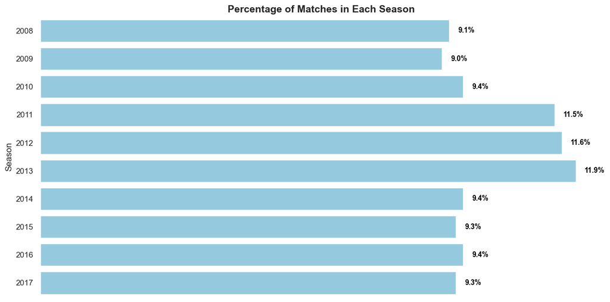

```python
# Count the number of matches per season and sort by season
season_counts = df_matches['season'].value_counts().sort_index()

# Calculate total matches and convert counts to percentages
total_matches = season_counts.sum()
season_percentages = (season_counts / total_matches) * 100

# Create a horizontal bar chart
plt.figure(figsize=(12, 6))
ax = sns.barplot(y=season_counts.index, x=season_percentages.values, color='skyblue', orient='h')

# Remove x-axis and unnecessary borders
sns.despine(top=True, right=True, bottom=True, left=True)

ax.xaxis.set_visible(False)
plt.xlabel(None)
plt.ylabel("Season", fontsize=12)
plt.title("Percentage of Matches in Each Season", fontsize=14, fontweight='bold')

for index, value in enumerate(season_percentages.values):
    ax.text(value +0.2, index, f"{value:.1f}%", va='center', fontsize=10, fontweight='bold', color='black')

# Show the plot
plt.tight_layout()
plt.show()
```

### **Summary of Findings**

1. The number of matches played in each season varies, with some seasons having a significantly higher proportion of matches.
2. The highest proportion of matches occurred in 2013, followed by 2012 and 2011, while 2009 had the lowest proportion.
3. The higher percentage of matches during 2011-2013 could be because of more number of teams participating in IPL during these seasons.

### **Reason for Choosing a Horizontal Bar Chart**

1. A **horizontal bar chart** improves readability when category labels (seasons) are long or numerous.
2. It effectively represents categorical data (seasons) against numerical values (proportion of matches).
3. It provides a clear visual hierarchy, making it easier to compare values at a glance.

### **Pre-attentive Attributes Used**

1. **Length:** The bar length directly corresponds to the proportion of matches, allowing for immediate comparison.
2. **Position:** Bars are aligned along a common axis, making differences between seasons immediately clear.

### **Gestalt Principles Used**

1. **Proximity:** Bars close together indicate they belong to the same dataset (seasons).
2. **Similarity:** The bars are uniformly styled with the same width and orientation, helping viewers recognize them as part of the same category.

### Question 2

#### Explore the proportion (percentage) of winning scores - win_by_runs, win_by_wickets for the entire time period from 2008 to 2019. Visualize using a single chart Write the python code in the below cell to create appropriate visual to perform the above task.

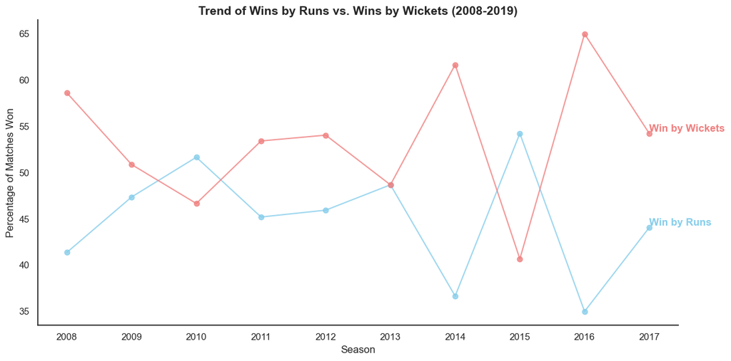

```python
# Count total matches per season
total_matches_per_season = df_matches.groupby('season').size()

# Count number of matches won by runs and by wickets and convert to percentage of total matches per season
win_by_runs_count = df_matches.groupby('season')['win_by_runs'].apply(lambda x: (x > 0).sum())
win_by_wickets_count = df_matches.groupby('season')['win_by_wickets'].apply(lambda x: (x > 0).sum())

win_data_percentage = pd.DataFrame({
    'win_by_runs': (win_by_runs_count / total_matches_per_season) * 100,
    'win_by_wickets': (win_by_wickets_count / total_matches_per_season) * 100
})

# Create the line chart
plt.figure(figsize=(12, 6))
sns.set_style("white")
plt.plot(win_data_percentage.index, win_data_percentage['win_by_runs'], marker='o', linestyle='-', color='skyblue', alpha=0.8)
plt.plot(win_data_percentage.index, win_data_percentage['win_by_wickets'], marker='o', linestyle='-', color='lightcoral', alpha=0.8)

# Labels and title
plt.xlabel("Season", fontsize=12)
plt.ylabel("Percentage of Matches Won", fontsize=12)
plt.title("Trend of Wins by Runs vs. Wins by Wickets (2008-2019)", fontsize=14, fontweight='bold')
plt.xticks(range(2008, 2018), [str(year) for year in range(2008, 2018)], rotation=0)

# Ensure axis lines remain visible and grid lines are removed
plt.gca().spines['top'].set_visible(False)
plt.gca().spines['right'].set_visible(False)
plt.gca().spines['left'].set_visible(True)
plt.gca().spines['bottom'].set_visible(True)

# Add text labels directly at the last point of each line
plt.text(win_data_percentage.index[-1], win_data_percentage['win_by_runs'].iloc[-1], 'Win by Runs',
         color='skyblue', fontsize=12, verticalalignment='bottom', fontweight='bold')

plt.text(win_data_percentage.index[-1], win_data_percentage['win_by_wickets'].iloc[-1], 'Win by Wickets',
         color='lightcoral', fontsize=12, verticalalignment='bottom', fontweight='bold')

# Show the plot
plt.tight_layout()
plt.show()
```

### **1. Summary of Findings**

1. On Analysing the dataset, we see that we have seasons data only between 2008 and 2017 and not until 2019.
2. The proportion of wins by wickets (red line) is generally higher in most seasons.
3. 2010 and 2015 had a higher percentage of wins by runs (light blue), making them exceptions.
4. 2013 stands out as the only season where both win types were exactly equal, showing a balance.
5. 2014 and 2016 had significantly more wins by wickets, with the highest peaks observed.
6. The trend fluctuates across seasons, with no long-term dominance of either win type.

### **3. Pre-Attentive Attributes Used**

1. **Color** - Different colors are used to distinguish between "Win by Runs" and "Win by Wickets."
2. **Position** - The data points and lines clearly show the rise and fall of the values over seasons.
3. **Line & markers** - The markers improve readability by making each data point distinct.

### **4. Gestalt Principles Used**

1. **Proximity** - The points connected by lines are grouped together, making it easy to follow trends.
2. **Continuity** - The smooth connection of points allows the viewer to see a continuous pattern, enhancing readability.
3. **Similarity** - The two lines share the same style (line thickness and markers), making it easy to compare trends despite different colors.

### Question 3

#### Perform a side by side visualization for the Toss Decisions, comparing the decision to field or bat across the period 2008-2019 in a single visual. Write the python code in the below cell to create appropriate visual to perform the above task.

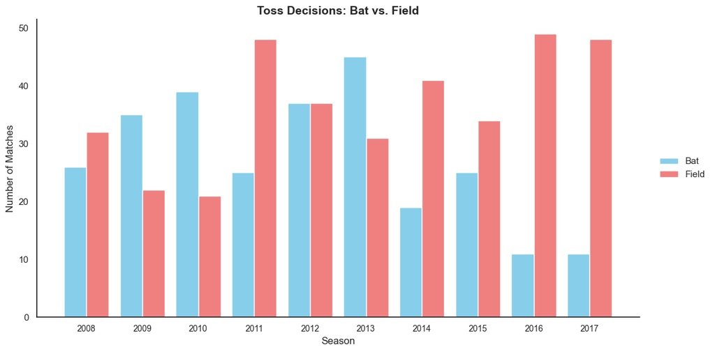

```python
# Count toss decisions for each season
toss_decision_counts = df_matches.groupby(['season', 'toss_decision']).size().unstack()

# Plotting the bar chart
fig, ax = plt.subplots(figsize=(12, 6))
bar_width = 0.4
index = np.arange(len(toss_decision_counts))

# Create bars for 'Bat' and 'Field' decisions
ax.bar(index, toss_decision_counts['bat'], bar_width, label='Bat', color='skyblue')
ax.bar(index + bar_width, toss_decision_counts['field'], bar_width, label='Field', color='lightcoral')

# Labels and title
ax.set_xlabel("Season", fontsize=12)
ax.set_ylabel("Number of Matches", fontsize=12)
ax.set_title("Toss Decisions: Bat vs. Field", fontsize=14, fontweight='bold')
ax.set_xticks(index + bar_width / 2)
ax.set_xticklabels(toss_decision_counts.index, rotation=0, fontsize=10)

# Remove unnecessary borders and grid lines
ax.spines['top'].set_visible(False)
ax.spines['right'].set_visible(False)
ax.yaxis.grid(False)

# Move legend to the right side
ax.legend(frameon=False, loc='center left', bbox_to_anchor=(1.02, 0.5))

plt.tight_layout()
plt.show()
```

### **2. The reason for selecting the chart type**

1. A **side-by-side bar chart** (grouped bar chart) allows for **easy comparison** between the two toss decisions over multiple years.
2. This makes it simpler to **observe trends, patterns, and shifts** in decision-making over time.
3. The chart provides an intuitive and effective way to compare two categorical values across multiple time points.

### **3. Pre-attentive attributes used (at least 2)**

1. **Color:** Different colors for "Bat" and "Field" help in **immediate differentiation** of the two categories.
2. **Position:** The **side-by-side placement** of bars makes it easy to compare toss decisions **for each season** without additional effort.

### **4. Gestalt principles used (at least 2)**

1. **Proximity:** Bars for the same season are **grouped closely together**, helping the viewer perceive them as a single unit of comparison.
2. **Similarity:** The same color is used for all "Bat" bars and another color for all "Field" bars, allowing the brain to **automatically associate** similar elements.
3. **Continuity:** The alignment of bars in a continuous sequence across years makes it easier to **follow the trend**.

### Question 4

#### Visualize the matches played by each team and find out which team played the maximum number of matches in IPL. Write the python code in the below cell to create appropriate visual to perform the above task.

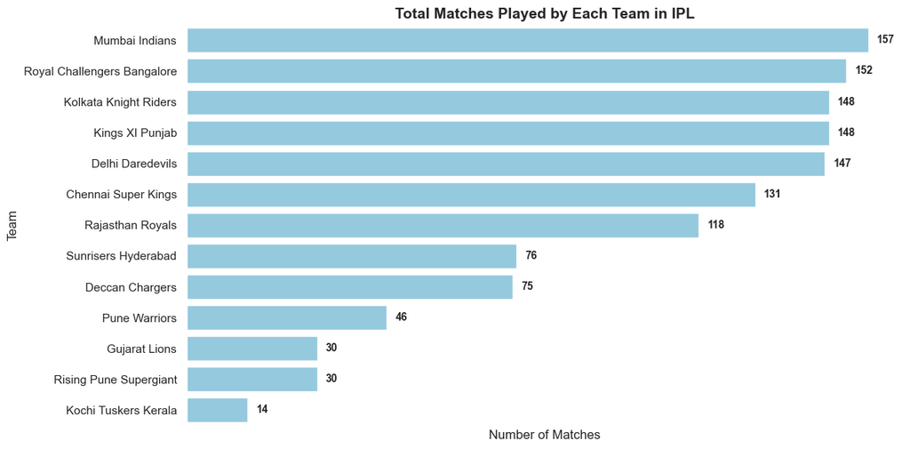

```python
# Calculate the total matches played by each team
team_matches = df_matches['team1'].value_counts() + df_matches['team2'].value_counts()
team_matches = team_matches.reset_index()
team_matches.columns = ['Team', 'Matches Played']

# Data inconsistency
# Merge 'Rising Pune Supergiant' and 'Rising Pune Supergiants' into one entry for consistency
team_matches.loc[team_matches['Team'] == "Rising Pune Supergiants", 'Team'] = "Rising Pune Supergiant"

# Recalculate the total matches played by Rising Pune Supergiant
team_matches = team_matches.groupby("Team", as_index=False).sum()
team_matches = team_matches.sort_values(by='Matches Played', ascending=False)

# Create the figure and axis
sns.set_style("whitegrid")
plt.figure(figsize=(12, 6))
ax = sns.barplot(x='Matches Played', y='Team', data=team_matches, color='skyblue')

# Add the total number at the end of each bar
for index, value in enumerate(team_matches["Matches Played"]):
    ax.text(value + 2, index, str(value), va='center', fontsize=10, fontweight='bold')

# Remove unnecessary borders and grid lines
ax.spines['top'].set_visible(False)
ax.spines['right'].set_visible(False)
ax.spines['left'].set_visible(False)
ax.spines['bottom'].set_visible(False)
ax.yaxis.grid(False)

# Labels and title
plt.xlabel("Number of Matches", fontsize=12)
plt.ylabel("Team", fontsize=12)
plt.title("Total Matches Played by Each Team in IPL", fontsize=14, fontweight="bold")
plt.tick_params(axis='x', which='both', bottom=False, labelbottom=False)

# Remove grids for a clean look
plt.grid(False)
plt.tight_layout()
plt.show()
```

### **1. Summarize your findings from the visual**

1. The visualization shows the **number of matches played by each team in IPL** history.
2. The **Mumbai Indians** played the **most matches** in IPL history, followed by **Royal Challengers Bangalore** and **Kings XI Punjab**.
3. The teams with the **least matches** played are **Kochi Tuskers Kerala and Rising Pune Supergiants**, likely due to their short participation in the league and early elimination from IPL and not have played playoffs.
4. Some teams have played significantly fewer matches, possibly due to **late entries or early exits from IPL**.
5. There is a noticeable gap between the top teams and the bottom teams, indicating long-term consistency in team participation.

### **3. Pre-attentive attributes used (at least 2)**

1. **Color:** The bars are in a single distinct color (**sky blue**) to keep focus on length comparisons.
2. **Length:** The bar lengths **naturally encode** the number of matches played, making comparisons effortless.

### **4. Gestalt principles used (at least 2)**

1. **Proximity:** Bars are aligned closely together, helping the brain perceive them as related data points.
2. **Similarity:** All bars have the same color and thickness, reinforcing the idea that they belong to the same category (teams).
3. **Continuity:** The bars are arranged in descending order, guiding the eye smoothly from the highest to the lowest value, making interpretation natural and intuitive.

### Question 5

#### Find out which venue had most number of matches played at. Plot the number of matches played at different venues and verify the same. Write the python code in the below cell to create the appropriate visual(single visual) to perform the above task .

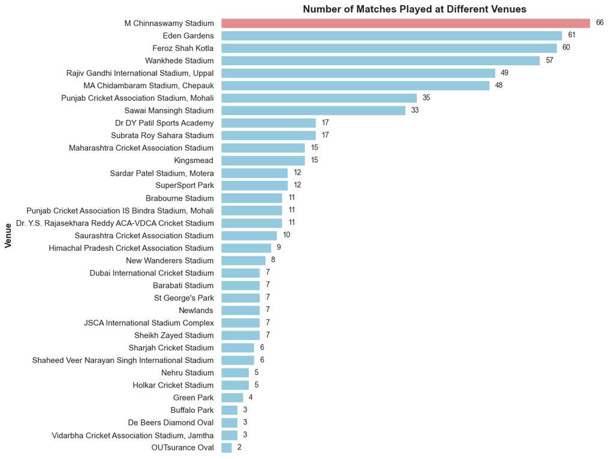

```python
# Count matches per venue
venue_counts = df_matches['venue'].value_counts()

#Top Venue
top_1_venues = venue_counts.nlargest(1).index
colors = ['lightcoral' if venue in top_1_venues else 'skyblue' for venue in venue_counts.index]

# Create figure and axis
sns.set_theme(style="whitegrid")
plt.figure(figsize=(12, 9))
ax = sns.barplot(x=venue_counts.values, y=venue_counts.index, palette=colors)

# Add text labels
for index, value in enumerate(venue_counts.values):
    ax.text(value + 1, index, str(value), va='center', fontsize=10)

# Remove spines and x-axis ticks for a cleaner look
sns.despine(left=True, bottom=True)
plt.xticks([])
plt.xlabel("")
plt.ylabel("Venue", fontsize=12, fontweight='bold')
plt.title("Number of Matches Played at Different Venues", fontsize=14, fontweight='bold')

# Show plot
plt.tight_layout()
plt.show()
```

### **1. Summarize your findings from the visual**

1. The **M Chinnaswamy Stadium** hosted the **highest** number of matches **(66)**. And is highlighted in lightcoral color for easy interpretation.
2. **Eden Gardens and Feroz Shah Kotla** are the **next top venues**, with **61** and **60** matches respectively.
3. The top six stadiums hosted significantly more matches than the rest.
4. Some stadiums, like **OUTsurance Oval** and **Vidarbha Cricket Association Stadium, Jamtha**, hosted very few matches.

### **2. The reason for selecting the chart type**

1. A horizontal bar chart is suitable since venue names are long and best displayed on the y-axis.
2. It effectively shows the ranking of venues based on the number of matches played.
3. The bars make it easy to compare different venues visually.

### **3. Pre-attentive attributes used (at least 2)**

1. **Color:** The top venue is highlighted in lightcoral color, making it stand out from the rest, which are in sky blue.
2. **Length:** The varying bar lengths help in quickly identifying the stadiums with the most matches.
3. **Position:** The **length of the horizontal lines** represents the number of matches, making it easy to compare. Bars are ordered for easy comparison from top to bottom.

### **4. Gestalt principles used (at least 2)**

1. **Continuity:** The bars are arranged in descending order, guiding the eye smoothly from the highest to the lowest value, making interpretation natural and intuitive.
2. **Similarity:** Bars of the same color (sky blue) are perceived as belonging to the same group (lower-ranked venues). The lightcoral bar differentiate the top 1 from the rest.

# Group's choice - 2 Marks

#### Frame 1 (more) question which will help in the EDA(Exploratory Data Analysis) of the given data set and answer the same using the best visual.

1. Write the question in a markdown cell
2. Below the question, in a coding cell, write the python code to create the visual to answer the question

#### **Question** :

**How does the toss-winning team's decision (bat first or field first) influence their winning percentage at different venues? We are considering the top 10 Venues based on number of matches hosted.**

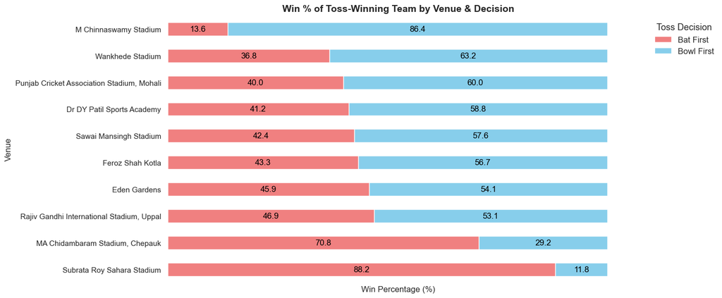

```python
# Select top 10 venues with the most matches
top_venues = df_matches['venue'].value_counts().head(10).index

# Filter data for only these venues
filtered_df = df_matches[df_matches['venue'].isin(top_venues)]

# Compute win percentage based on toss decision
toss_stats = (
    filtered_df.groupby(['venue', 'toss_decision'])['winner']
    .count()
    .unstack()
    .fillna(0)
)

toss_stats = toss_stats.div(toss_stats.sum(axis=1), axis=0) * 100

# Sort by 'Bat First' win percentage in descending order
toss_stats = toss_stats.sort_values(by="bat", ascending=False)

# Plot stacked bar chart
sns.set_style("white")
fig, ax = plt.subplots(figsize=(12, 7))
toss_stats.plot(kind='barh', stacked=True, color=["lightcoral", "skyblue"], ax=ax)

# Add percentage labels inside the bars
for i, (bat, bowl) in enumerate(zip(toss_stats.iloc[:, 0], toss_stats.iloc[:, 1])):
    ax.text(bat / 2, i, f"{bat:.1f}", ha="center", va="center", fontsize=12, color="black")
    ax.text(bat + bowl / 2, i, f"{bowl:.1f}", ha="center", va="center", fontsize=12, color="black")

# Labels and title
plt.xlabel("Win Percentage (%)", fontsize=12)
plt.ylabel("Venue", fontsize=12)
plt.title("Win % of Toss-Winning Team by Venue & Decision", fontsize=14, fontweight="bold")
plt.tick_params(axis='x', which='both', bottom=False, labelbottom=False)

# Adjust legend position
plt.legend(["Bat First", "Bowl First"], title="Toss Decision", fontsize=12, title_fontsize=13, frameon=False, loc='upper right', bbox_to_anchor=(1.2, 1))

# Remove axis borders
sns.despine(left=True, bottom=True)
ax.grid(False)

# Show plot
plt.show()
```

### **4. Gestalt principles used (at least 2)**

1. **Proximity** – The bars for each venue are grouped together, making it easy to compare the two decisions.
2. **Similarity** – The color coding ensures that viewers can quickly identify patterns in the dataset. In our case, **lightcoral and skyblue** colors are used to clearly differentiate between **"Bat First"** and **"Bowl First"** decisions.

# ************ END OF ASSIGNMENT ****************